# Variable selection - potential examples

### LASSO

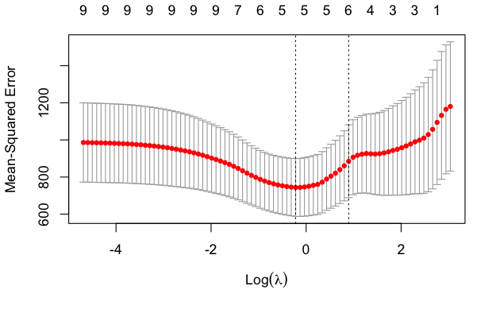

```r
X <-
  cystfibr %>%
  select(-pemax)

X <- as.matrix(X)

cfib.cv <- cv.glmnet(X, cystfibr$pemax)

plot(cfib.cv)
```

```r
cfib.las <- glmnet(X, cystfibr$pemax, lambda = cfib.cv$lambda.min)

cfib.las$beta
```

[output not shown]

### Cross-validation

```r
##  Function to get predicted values
##  See James et al., p. 249

predict.regsubsets <- function(object, newdata, id,...){
  form <- as.formula(object$call[[2]])
  mat <- model.matrix(form, newdata)
  coefi <- coef(object, id = id)
  xvars <- names(coefi)
  mat[ , xvars]%*%coefi
}
```

```r
folds <- sample(1:k, nrow(cystfibr), replace = T)


folds
```

```
 [1]  9  5  5  9  7  5  2  6  1  8  7  8  8  3 10  3 10  9  1  3  4  2  7
[24]  9  9
```

```r
table(folds)
```

```
folds
 1  2  3  4  5  6  7  8  9 10
 2  2  3  1  3  1  3  3  5  2
```

```r
mean.cv.errors <- apply(cv.errors, 2, mean, na.rm = T)
mean.cv.errors

which.min(mean.cv.errors)
```

[output not shown]

```r
plot(mean.cv.errors, type = "b")
```

[output not shown]

```r
reg.best <- regsubsets(pemax ~ ., data = cystfibr, nvmax = 9)

reg.best.ind <- which.min(mean.cv.errors)

coef(reg.best, reg.best.ind)
```

```
(Intercept)      weight
  63.545644    1.186709
```

Four predictor model

```r
coef(reg.best, 4)
```

```
(Intercept)      weight         bmp        fev1          rv
 63.9466933   1.7489143  -1.3772433   1.5476984   0.1257152
```

```r
cfib.lm2 <- lm(pemax ~ weight + bmp + fev1, data = cystfibr)

summary(cfib.lm2)
```

```
Call:
lm(formula = pemax ~ weight + bmp + fev1, data = cystfibr)

Residuals:
    Min      1Q  Median      3Q     Max
-42.388 -13.496   3.991  14.856  40.373

Coefficients:
            Estimate Std. Error t value Pr(>|t|)
(Intercept) 126.3336    34.7199   3.639 0.001536 **
weight        1.5365     0.3644   4.216 0.000387 ***
bmp          -1.4654     0.5793  -2.530 0.019486 *
fev1          1.1086     0.5144   2.155 0.042893 *
---
Signif. codes:  0 ‘***’ 0.001 ‘**’ 0.01 ‘*’ 0.05 ‘.’ 0.1 ‘ ’ 1

Residual standard error: 23.44 on 21 degrees of freedom
Multiple R-squared:   0.57, Adjusted R-squared:  0.5086
F-statistic: 9.279 on 3 and 21 DF,  p-value: 0.000418
```

```r
vif(cfib.lm2)
```

```
  weight      bmp     fev1
1.858322 2.112663 1.448971
```

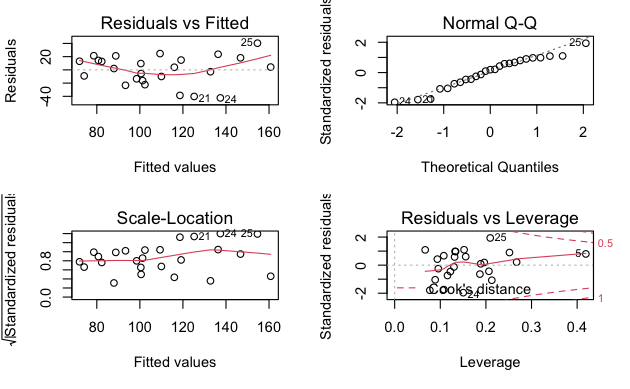

```r
par(mfrow = c(2, 2))
plot(cfib.lm2)
par(mfrow = c(2, 2))
```

### Stepwise

```r
step(cfib.lm1, direction = "both")
```

```
Start:  AIC=169.11
pemax ~ age + sex + height + weight + bmp + fev1 + rv + frc +
    tlc

         Df Sum of Sq     RSS    AIC
- sex     1     37.90  9769.2 167.20
- tlc     1     92.40  9823.7 167.34
- height  1    158.32  9889.6 167.51
- age     1    181.81  9913.1 167.57
- frc     1    254.55  9985.8 167.75
- fev1    1    648.45 10379.7 168.72
- rv      1    653.78 10385.0 168.73
<none>                 9731.2 169.11
- weight  1   1441.21 11172.5 170.56
- bmp     1   1480.12 11211.4 170.65

Step:  AIC=167.2
pemax ~ age + height + weight + bmp + fev1 + rv + frc + tlc

         Df Sum of Sq     RSS    AIC
- tlc     1    115.94  9885.1 165.50
- height  1    131.21  9900.4 165.54
- age     1    145.55  9914.7 165.57
- frc     1    221.50  9990.7 165.76
- rv      1    636.15 10405.3 166.78
<none>                 9769.2 167.20
- weight  1   1446.23 11215.4 168.65
- bmp     1   1474.72 11243.9 168.72
+ sex     1     37.90  9731.2 169.11
- fev1    1   1770.40 11539.6 169.37

Step:  AIC=165.5
pemax ~ age + height + weight + bmp + fev1 + rv + frc

         Df Sum of Sq     RSS    AIC
- frc     1    133.16 10018.3 163.83
- height  1    215.79 10100.9 164.04
- age     1    252.20 10137.3 164.13
- rv      1    543.55 10428.6 164.84
<none>                 9885.1 165.50
```

[output cut: 42 more lines]

```
+ tlc     1     197.1 10158 162.18
+ height  1     191.0 10164 162.19
+ age     1     178.1 10176 162.22
+ frc     1       3.4 10351 162.65
+ sex     1       2.4 10352 162.65
- bmp     1    3072.6 13427 165.15
- fev1    1    3717.1 14072 166.33
- weight  1   10930.2 21285 176.67

Call:
lm(formula = pemax ~ weight + bmp + fev1 + rv, data = cystfibr)

Coefficients:
(Intercept)       weight          bmp         fev1           rv
    63.9467       1.7489      -1.3772       1.5477       0.1257
```

```r
drop1(cfib.lm1, test = "F")   # So called 'type II' ANOVA
```

```
Single term deletions

Model:
pemax ~ age + sex + height + weight + bmp + fev1 + rv + frc +
    tlc
       Df Sum of Sq     RSS    AIC F value Pr(>F)
<none>               9731.2 169.11
age     1    181.81  9913.1 167.57  0.2803 0.6043
sex     1     37.90  9769.2 167.20  0.0584 0.8123
height  1    158.32  9889.6 167.51  0.2440 0.6285
weight  1   1441.21 11172.5 170.56  2.2215 0.1568
bmp     1   1480.12 11211.4 170.65  2.2815 0.1517
fev1    1    648.45 10379.7 168.72  0.9995 0.3333
rv      1    653.78 10385.0 168.73  1.0077 0.3314
frc     1    254.55  9985.8 167.75  0.3924 0.5405
tlc     1     92.40  9823.7 167.34  0.1424 0.7112
```

```r
drop1(cfib.lm1, test = "Chisq")
```

```
Single term deletions

Model:
pemax ~ age + sex + height + weight + bmp + fev1 + rv + frc +
    tlc
       Df Sum of Sq     RSS    AIC Pr(>Chi)
<none>               9731.2 169.11
age     1    181.81  9913.1 167.57  0.49633
sex     1     37.90  9769.2 167.20  0.75524
height  1    158.32  9889.6 167.51  0.52531
weight  1   1441.21 11172.5 170.56  0.06315 .
bmp     1   1480.12 11211.4 170.65  0.05992 .
fev1    1    648.45 10379.7 168.72  0.20411
rv      1    653.78 10385.0 168.73  0.20232
frc     1    254.55  9985.8 167.75  0.42171
tlc     1     92.40  9823.7 167.34  0.62691
---
Signif. codes:  0 ‘***’ 0.001 ‘**’ 0.01 ‘*’ 0.05 ‘.’ 0.1 ‘ ’ 1
```

## Analysis approach: discipline expert in control

Controlling model selection manually allows researcher to exert some logical control over the process (Dalgaard, ISwR, p. 190).

Remove the four lung function variables: tlc, frc, rv, fev1

Using Harrell’s recommendation, it might be better to do this in one step using the AIC.

Approach below should probably be done using AIC.

Full model

```r
cfib.lm1 <- lm(pemax ~ ., data = cystfibr)

summary(cfib.lm1)
```

```
Call:
lm(formula = pemax ~ ., data = cystfibr)

Residuals:
    Min      1Q  Median      3Q     Max
-37.338 -11.532   1.081  13.386  33.405

Coefficients:
            Estimate Std. Error t value Pr(>|t|)
(Intercept) 176.0582   225.8912   0.779    0.448
age          -2.5420     4.8017  -0.529    0.604
sex          -3.7368    15.4598  -0.242    0.812
height       -0.4463     0.9034  -0.494    0.628
weight        2.9928     2.0080   1.490    0.157
bmp          -1.7449     1.1552  -1.510    0.152
fev1          1.0807     1.0809   1.000    0.333
rv            0.1970     0.1962   1.004    0.331
frc          -0.3084     0.4924  -0.626    0.540
tlc           0.1886     0.4997   0.377    0.711

Residual standard error: 25.47 on 15 degrees of freedom
Multiple R-squared:  0.6373,    Adjusted R-squared:  0.4197
F-statistic: 2.929 on 9 and 15 DF,  p-value: 0.03195
```

### Remove other lung function indicators first

```r
cfib.lm1a <- update(cfib.lm1, . ~ . - tlc)

summary(cfib.lm1a)
```

```
Call:
lm(formula = pemax ~ age + sex + height + weight + bmp + fev1 +
    rv + frc, data = cystfibr)

Residuals:
    Min      1Q  Median      3Q     Max
-38.072 -10.067   0.113  13.526  36.990

Coefficients:
            Estimate Std. Error t value Pr(>|t|)
(Intercept) 221.8055   185.4350   1.196   0.2491
age          -3.1346     4.4144  -0.710   0.4879
sex          -4.6933    14.8363  -0.316   0.7558
height       -0.5428     0.8428  -0.644   0.5286
weight        3.3157     1.7672   1.876   0.0790 .
bmp          -1.9403     1.0047  -1.931   0.0714 .
fev1          1.0183     1.0392   0.980   0.3417
rv            0.1857     0.1887   0.984   0.3396
frc          -0.2605     0.4628  -0.563   0.5813
---
Signif. codes:  0 ‘***’ 0.001 ‘**’ 0.01 ‘*’ 0.05 ‘.’ 0.1 ‘ ’ 1

Residual standard error: 24.78 on 16 degrees of freedom
Multiple R-squared:  0.6339,    Adjusted R-squared:  0.4508
F-statistic: 3.463 on 8 and 16 DF,  p-value: 0.01649
```

```r
cfib.lm1b <- update(cfib.lm1a, . ~ . - frc)

summary(cfib.lm1b)
```

```
Call:
lm(formula = pemax ~ age + sex + height + weight + bmp + fev1 +
    rv, data = cystfibr)

Residuals:
    Min      1Q  Median      3Q     Max
-39.425 -12.391   3.834  14.797  36.693

Coefficients:
             Estimate Std. Error t value Pr(>|t|)
(Intercept) 166.71822  154.31294   1.080   0.2951
age          -1.81783    3.66773  -0.496   0.6265
sex           0.10239   11.89990   0.009   0.9932
height       -0.40981    0.79257  -0.517   0.6118
weight        2.87386    1.55120   1.853   0.0814 .
bmp          -1.94971    0.98415  -1.981   0.0640 .
fev1          1.41526    0.74788   1.892   0.0756 .
rv            0.09567    0.09798   0.976   0.3425
---
Signif. codes:  0 ‘***’ 0.001 ‘**’ 0.01 ‘*’ 0.05 ‘.’ 0.1 ‘ ’ 1

Residual standard error: 24.28 on 17 degrees of freedom
Multiple R-squared:  0.6266,    Adjusted R-squared:  0.4729
F-statistic: 4.076 on 7 and 17 DF,  p-value: 0.008452
```

```r
cfib.lm1c <- update(cfib.lm1b, . ~ . - rv)

summary(cfib.lm1c)
```

```
Call:
lm(formula = pemax ~ age + sex + height + weight + bmp + fev1,
    data = cystfibr)

Residuals:
    Min      1Q  Median      3Q     Max
-43.238  -7.403  -0.081  15.534  36.028

Coefficients:
            Estimate Std. Error t value Pr(>|t|)
(Intercept) 260.6313   120.5215   2.163   0.0443 *
age          -2.9062     3.4898  -0.833   0.4159
sex          -1.2115    11.8083  -0.103   0.9194
height       -0.6067     0.7655  -0.793   0.4384
weight        3.3463     1.4719   2.273   0.0355 *
bmp          -2.3042     0.9136  -2.522   0.0213 *
fev1          1.0274     0.6329   1.623   0.1219
---
Signif. codes:  0 ‘***’ 0.001 ‘**’ 0.01 ‘*’ 0.05 ‘.’ 0.1 ‘ ’ 1

Residual standard error: 24.24 on 18 degrees of freedom
Multiple R-squared:  0.6057,    Adjusted R-squared:  0.4743
F-statistic: 4.608 on 6 and 18 DF,  p-value: 0.00529
```

```r
cfib.lm1d <- update(cfib.lm1c, . ~ . - fev1)

summary(cfib.lm1d)
```

```
Call:
lm(formula = pemax ~ age + sex + height + weight + bmp, data = cystfibr)

Residuals:
    Min      1Q  Median      3Q     Max
-43.194  -9.412  -2.425   9.157  40.112

Coefficients:
            Estimate Std. Error t value Pr(>|t|)
(Intercept) 280.4482   124.9556   2.244   0.0369 *
age          -3.0750     3.6352  -0.846   0.4081
sex         -11.5281    10.3720  -1.111   0.2802
height       -0.6853     0.7962  -0.861   0.4001
weight        3.5546     1.5281   2.326   0.0312 *
bmp          -1.9613     0.9263  -2.117   0.0476 *
---
Signif. codes:  0 ‘***’ 0.001 ‘**’ 0.01 ‘*’ 0.05 ‘.’ 0.1 ‘ ’ 1

Residual standard error: 25.27 on 19 degrees of freedom
Multiple R-squared:  0.548, Adjusted R-squared:  0.429
F-statistic: 4.606 on 5 and 19 DF,  p-value: 0.006388
```

Next, focus on reducing variables related to patients’ physical size. Do not remove weight and bmp because of small p values.

```r
cfib.lm1e <- update(cfib.lm1d, . ~ . - sex)

summary(cfib.lm1e)
```

```
Call:
lm(formula = pemax ~ age + height + weight + bmp, data = cystfibr)

Residuals:
    Min      1Q  Median      3Q     Max
-41.501 -15.460  -2.838  11.082  42.991

Coefficients:
            Estimate Std. Error t value Pr(>|t|)
(Intercept) 274.5307   125.5745   2.186   0.0409 *
age          -3.0832     3.6566  -0.843   0.4091
height       -0.6985     0.8008  -0.872   0.3934
weight        3.6338     1.5354   2.367   0.0282 *
bmp          -1.9621     0.9317  -2.106   0.0480 *
---
Signif. codes:  0 ‘***’ 0.001 ‘**’ 0.01 ‘*’ 0.05 ‘.’ 0.1 ‘ ’ 1

Residual standard error: 25.41 on 20 degrees of freedom
Multiple R-squared:  0.5186,    Adjusted R-squared:  0.4223
F-statistic: 5.386 on 4 and 20 DF,  p-value: 0.004137
```

```r
cfib.lm1f <- update(cfib.lm1e, . ~ . - age)

summary(cfib.lm1f)
```

```
Call:
lm(formula = pemax ~ height + weight + bmp, data = cystfibr)

Residuals:
    Min      1Q  Median      3Q     Max
-41.794 -11.764  -1.218  13.202  43.631

Coefficients:
            Estimate Std. Error t value Pr(>|t|)
(Intercept) 245.3936   119.8927   2.047   0.0534 .
height       -0.8264     0.7808  -1.058   0.3019
weight        2.7717     1.1377   2.436   0.0238 *
bmp          -1.4876     0.7375  -2.017   0.0566 .
---
Signif. codes:  0 ‘***’ 0.001 ‘**’ 0.01 ‘*’ 0.05 ‘.’ 0.1 ‘ ’ 1

Residual standard error: 25.24 on 21 degrees of freedom
Multiple R-squared:  0.5015,    Adjusted R-squared:  0.4302
F-statistic: 7.041 on 3 and 21 DF,  p-value: 0.00187
```

```r
cfib.lm1g <- update(cfib.lm1f, . ~ . - height)

summary(cfib.lm1g)
```

```
Call:
lm(formula = pemax ~ weight + bmp, data = cystfibr)

Residuals:
    Min      1Q  Median      3Q     Max
-42.924 -13.399   4.361  16.642  48.404

Coefficients:
            Estimate Std. Error t value Pr(>|t|)
(Intercept) 124.8297    37.4786   3.331 0.003033 **
weight        1.6403     0.3900   4.206 0.000365 ***
bmp          -1.0054     0.5814  -1.729 0.097797 .
---
Signif. codes:  0 ‘***’ 0.001 ‘**’ 0.01 ‘*’ 0.05 ‘.’ 0.1 ‘ ’ 1

Residual standard error: 25.31 on 22 degrees of freedom
Multiple R-squared:  0.4749,    Adjusted R-squared:  0.4271
F-statistic: 9.947 on 2 and 22 DF,  p-value: 0.0008374
```

### Removing blocks of variables

```r
cfib.lm11 <- update(cfib.lm1, . ~ . - fev1 - rv - frc - tlc)

c(AIC(cfib.lm1), AIC(cfib.lm11))
```

```
[1] 242.0525 239.5593
```

```r
summary(cfib.lm11)
```

```
Call:
lm(formula = pemax ~ age + sex + height + weight + bmp, data = cystfibr)

Residuals:
    Min      1Q  Median      3Q     Max
-43.194  -9.412  -2.425   9.157  40.112

Coefficients:
            Estimate Std. Error t value Pr(>|t|)
(Intercept) 280.4482   124.9556   2.244   0.0369 *
age          -3.0750     3.6352  -0.846   0.4081
sex         -11.5281    10.3720  -1.111   0.2802
height       -0.6853     0.7962  -0.861   0.4001
weight        3.5546     1.5281   2.326   0.0312 *
bmp          -1.9613     0.9263  -2.117   0.0476 *
---
Signif. codes:  0 ‘***’ 0.001 ‘**’ 0.01 ‘*’ 0.05 ‘.’ 0.1 ‘ ’ 1

Residual standard error: 25.27 on 19 degrees of freedom
Multiple R-squared:  0.548, Adjusted R-squared:  0.429
F-statistic: 4.606 on 5 and 19 DF,  p-value: 0.006388
```

### Replace height and weight with BMI

One possibility is to replace height and weight in model by BMI ( = wt(kg) / sqrt( ht(m) ) ), although original researchers did not do this.

```r
cystfibr2 <-
  cystfibr %>%
  mutate(bmi = weight / sqrt( height / 100))

cystfibr3 <-
  cystfibr2 %>%
  select(-height, -weight)
```

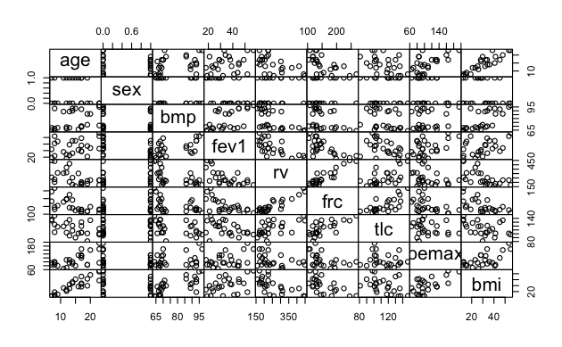

```r
pairs(cystfibr3, gap = 0)
```

```r
cfib.lm20 <- lm(pemax ~ ., data = cystfibr3)

summary(cfib.lm20)
```

```
Call:
lm(formula = pemax ~ ., data = cystfibr3)

Residuals:
    Min      1Q  Median      3Q     Max
-36.189 -13.774   4.345  14.393  31.699

Coefficients:
            Estimate Std. Error t value Pr(>|t|)
(Intercept)  82.2262   133.7391   0.615    0.547
age          -2.2343     4.8164  -0.464    0.649
sex          -3.6294    15.0565  -0.241    0.813
bmp          -1.6349     1.0985  -1.488    0.156
fev1          1.2764     0.9951   1.283    0.218
rv            0.2056     0.1937   1.061    0.304
frc          -0.2932     0.4796  -0.611    0.550
tlc           0.2954     0.4640   0.637    0.533
bmi           3.4242     2.2065   1.552    0.140

Residual standard error: 24.98 on 16 degrees of freedom
Multiple R-squared:  0.628, Adjusted R-squared:  0.442
F-statistic: 3.376 on 8 and 16 DF,  p-value: 0.01833
```

P values are large, although global P value is small.

```r
vif(cfib.lm20)
```

```
      age       sex       bmp      fev1        rv       frc       tlc
22.837834  2.238240  6.690327  4.775354 10.677821 16.912455  2.384880
      bmi
29.646456
```

LASSO with bmi.

### LASSO

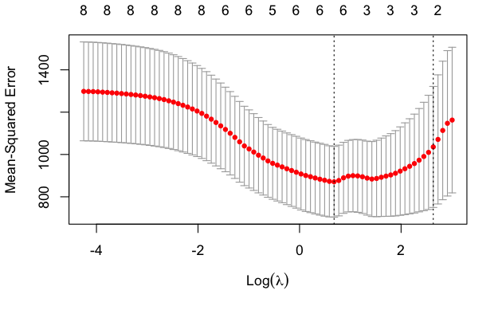

```r
X <-
  cystfibr3 %>%
  select(-pemax)

X <- as.matrix(X)

cfib.cv20 <- cv.glmnet(X, cystfibr3$pemax)

plot(cfib.cv20)
```

```r
cfib.las20 <- glmnet(X, cystfibr3$pemax, lambda = cfib.cv20$lambda.min)

cfib.las20$beta
```

```
8 x 1 sparse Matrix of class "dgCMatrix"
              s0
age   1.66867166
sex   .
bmp  -0.52244443
fev1  0.98146951
rv    0.02910786
frc   .
tlc   0.15677091
bmi   1.04849386
```

Cross-validation on data with bmi.

```r
##  Set no. of folds, k

k <- 25

#RNGversion(vstr = "4.0.2")
#set.seed(1)

######
######  Run one of the next two lines of code only
######

##  Next line for leave-one-out cross validation
folds <- sample(1:k, nrow(cystfibr3), replace = F)

##  Next line for k-fold cross validation
#folds <- sample(1:k, nrow(scapula_1), replace = T)


folds
```

```
 [1] 11  6  8 12 10 17 23  2 13  5  7  4 15 16 25 21  3 22  9 14  1 24 20
[24] 18 19
```

```r
table(folds)
```

```
folds
 1  2  3  4  5  6  7  8  9 10 11 12 13 14 15 16 17 18 19 20 21 22 23 24
 1  1  1  1  1  1  1  1  1  1  1  1  1  1  1  1  1  1  1  1  1  1  1  1
25
 1
```

```r
cv.errors <- matrix(NA , nrow = k, ncol = 8,
                    dimnames = list(NULL, paste(1:8)))

for(j in 1:k){
  best.fit <- regsubsets(pemax ~ ., data = cystfibr3[folds != j, ],
                         nvmax = 8)

  for(i in 1:8){
    pred <- predict(best.fit, cystfibr3[folds == j, ], id = i)
    cv.errors[j,  i] = mean((cystfibr3$pemax[folds == j] - pred)^2)
  }
}
```

```r
mean.cv.errors <- apply(cv.errors, 2, mean, na.rm = T)
mean.cv.errors
```

```
        1         2         3         4         5         6         7
1005.2546  945.6966  727.8796  777.0390  893.7645  936.6984  970.1531
        8
 998.5744
```

```r
which.min(mean.cv.errors)
```

```
3
3
```

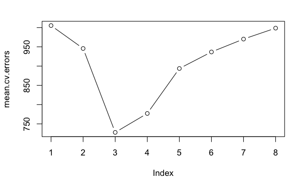

```r
plot(mean.cv.errors, type = "b")
```

Find best 3-predictor model using full data set

```r
reg.best <- regsubsets(pemax ~ ., data = cystfibr3, nvmax = 8)

reg.best.ind <- which.min(mean.cv.errors)

coef(reg.best, reg.best.ind)
```

```
(Intercept)         bmp        fev1         bmi
 124.951583   -1.575516    1.147675    2.228678
```

## Sleep in mammals

OzDASL

http://www.statsci.org/data/general/sleep.html

Response variable: the three sleep variables, total hours of sleep, dreaming sleep or non-dreaming sleep; or proportion of sleep spent dreaming

```r
sleep <- read.table(
  file = "http://www.statsci.org/data/general/sleep.txt",
  sep = "", header = T)

write.csv(sleep, "../data/sleep_mammals_OzDASL.csv", row.names = F)

str(sleep)
```

```
'data.frame':   62 obs. of  11 variables:
 $ Species    : chr  "Africanelephant" "Africangiantpouchedrat" "ArcticFox" "Arcticgroundsquirrel" ...
 $ BodyWt     : num  6654 1 3.38 0.92 2547 ...
 $ BrainWt    : num  5712 6.6 44.5 5.7 4603 ...
 $ NonDreaming: num  NA 6.3 NA NA 2.1 9.1 15.8 5.2 10.9 8.3 ...
 $ Dreaming   : num  NA 2 NA NA 1.8 0.7 3.9 1 3.6 1.4 ...
 $ TotalSleep : num  3.3 8.3 12.5 16.5 3.9 9.8 19.7 6.2 14.5 9.7 ...
 $ LifeSpan   : num  38.6 4.5 14 NA 69 27 19 30.4 28 50 ...
 $ Gestation  : num  645 42 60 25 624 180 35 392 63 230 ...
 $ Predation  : int  3 3 1 5 3 4 1 4 1 1 ...
 $ Exposure   : int  5 1 1 2 5 4 1 5 2 1 ...
 $ Danger     : int  3 3 1 3 4 4 1 4 1 1 ...
```

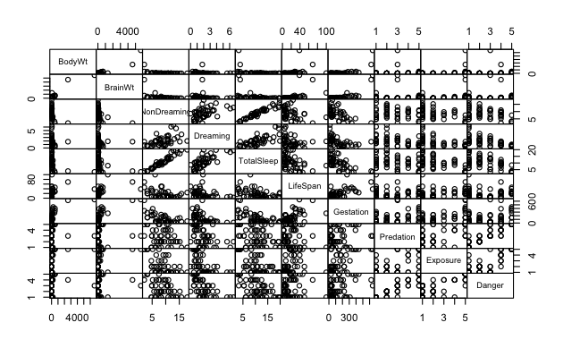

```r
sleep2 <-
  sleep %>%
  select(-Species)

pairs(sleep2, gap = 0)
```

Transformations

```r
sleep$logBodyWt <- log(sleep$BodyWt)

sleep$logBrainWt <- log(sleep$BrainWt)
```

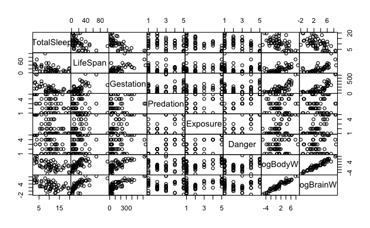

```r
sleep2 <-
  sleep %>%
  select(-Species, -BodyWt, -BrainWt, -NonDreaming, -Dreaming)

pairs(sleep2, gap = 0)
```

```r
sleep2 <- na.omit(sleep2)
```

```r
sleep.lm1 <- lm(TotalSleep ~ ., data = sleep2)

summary(sleep.lm1)
```

```
Call:
lm(formula = TotalSleep ~ ., data = sleep2)

Residuals:
    Min      1Q  Median      3Q     Max
-6.5584 -1.5343 -0.2021  1.4630  6.0387

Coefficients:
             Estimate Std. Error t value Pr(>|t|)
(Intercept) 17.148539   1.562319  10.976 4.74e-14 ***
LifeSpan     0.014995   0.032532   0.461 0.647175
Gestation   -0.008116   0.004732  -1.715 0.093559 .
Predation    1.949940   0.946696   2.060 0.045510 *
Exposure     0.828047   0.560568   1.477 0.146921
Danger      -4.193364   1.120484  -3.742 0.000536 ***
logBodyWt    0.128558   0.459446   0.280 0.780964
logBrainWt  -0.841289   0.629720  -1.336 0.188586
---
Signif. codes:  0 ‘***’ 0.001 ‘**’ 0.01 ‘*’ 0.05 ‘.’ 0.1 ‘ ’ 1

Residual standard error: 2.765 on 43 degrees of freedom
Multiple R-squared:  0.6997,    Adjusted R-squared:  0.6508
F-statistic: 14.31 on 7 and 43 DF,  p-value: 1.976e-09
```

```r
vif(sleep.lm1)
```

```
  LifeSpan  Gestation  Predation   Exposure     Danger  logBodyWt
  2.507122   2.971837  12.978738   5.121031  16.732626  13.903451
logBrainWt
 16.568907
```